# homework2

b06208016楊鎧綾

September 24, 2018

# 2.8

## a

the sample size of the study is 2391

## b

the observational units is the people aged 65 or older

## c

two variables are “attending frequent religious or not”" and “blood pressure”

## d

我覺得研究者將observed data當成樣本資料，而且使用敘述統計，描述那些observation的variable之間的關係。  
但新聞直接將他當成母體，而做出容易誤導觀眾的報導。

# 2.20

explanatory variable is “smoker or lifetime nonsmokers” and it is categorical variables  
response variable is “developed desease or not” and it is categorical variables, too

# 2.30

## a

```r
getab=1700
all=2470
paste(round((getab/all)*100, 2), "%", sep="")
```

```
## [1] "68.83%"
```

## b

```r
absb=1056
paste(round((absb/getab)*100, 2), "%", sep="")
```

```
## [1] "62.12%"
```

## c

```r
getc=657
csb=300
paste(round((csb/getc)*100, 2), "%", sep="")
```

```
## [1] "45.66%"
```

## d

```r
getdf=113
dsb=41
paste(round((dsb/getdf)*100, 2), "%", sep="")
```

```
## [1] "36.28%"
```

# 2.32

## a

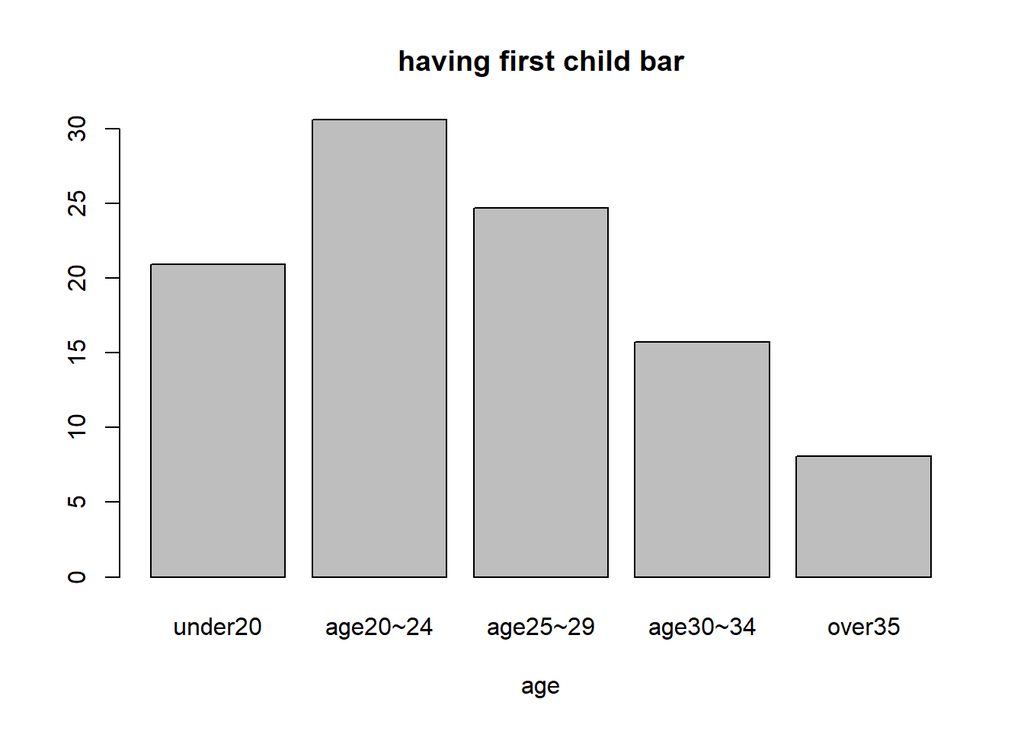

```r
age=c("under20","age20~24","age25~29","age30~34","over35")
per=c(20.9,30.6,24.7,15.7,8.1)
barplot(per,names.arg = age,xlab="age", main="having first child bar")
```

## b

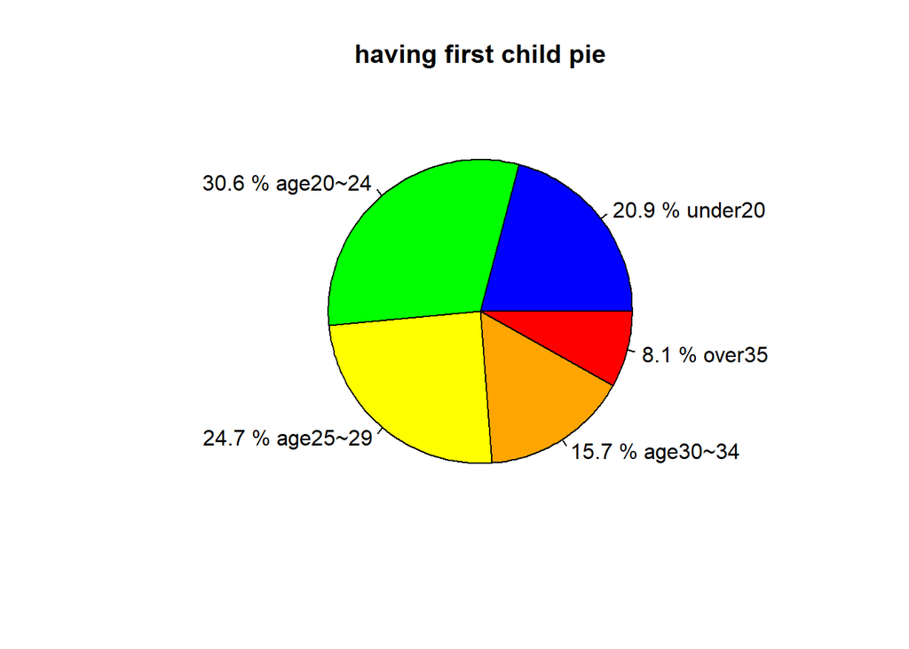

```r
pie(per, labels = paste(per,"%",age), col=c("blue","green","yellow","orange","red"), main="having first child pie")
```

## c

圓餅圖且可以清楚的比較比例資料，可以明顯地知道全部加起來是100%  
而長條圖可以看到在何年齡生第一胎的人較多(時間關係，因為像是34和35歲，雖然只差一歲卻被分成兩群，在圓餅圖中不容易看到群與群之間的關係，但長條圖可以)，而且可以直接對照比例  
大致上來說我喜歡長條圖，他容易判讀而且可以觀察較多資訊

# 2.46

```r
cd=c(220,20,50,450,300,30,20,50,200,35,25,50,250,100,0,100,20,13,200,2,125,150,90,60)
stem(cd,scale=1)
```

```
##
##   The decimal point is 2 digit(s) to the right of the |
##
##   0 | 00122233455569
##   1 | 0035
##   2 | 0025
##   3 | 0
##   4 | 5
```

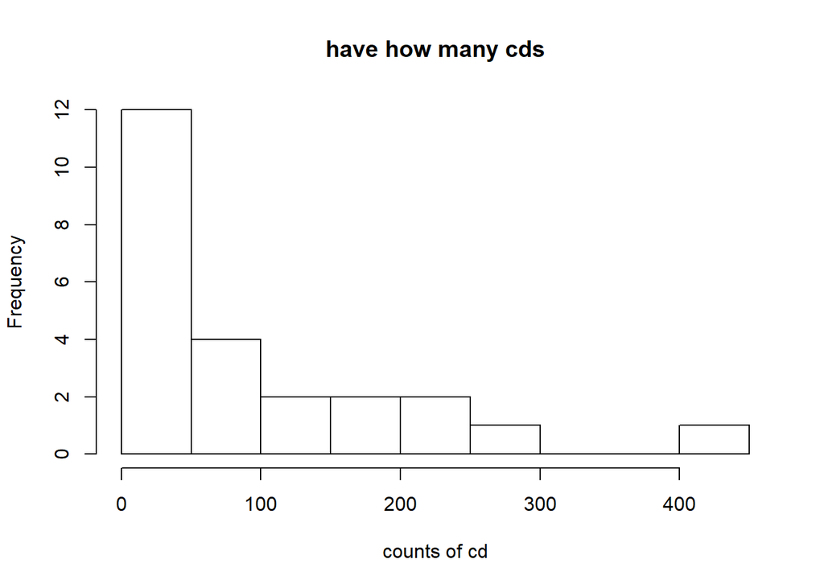

```r
hist(x=cd,breaks=10,xlab="counts of cd",main="have how many cds")
```

# 2.52

```r
ages=c(42,47,48,49,49,50,50,50,50,51,51,51,52,54,54,55,55,55,55,56,57,57,57,57,57,58,58,59,59,60,60,60,61,61,62,62,62,62,62,63,63,64,64,64,64,67,67,69,74,78)
```

## a

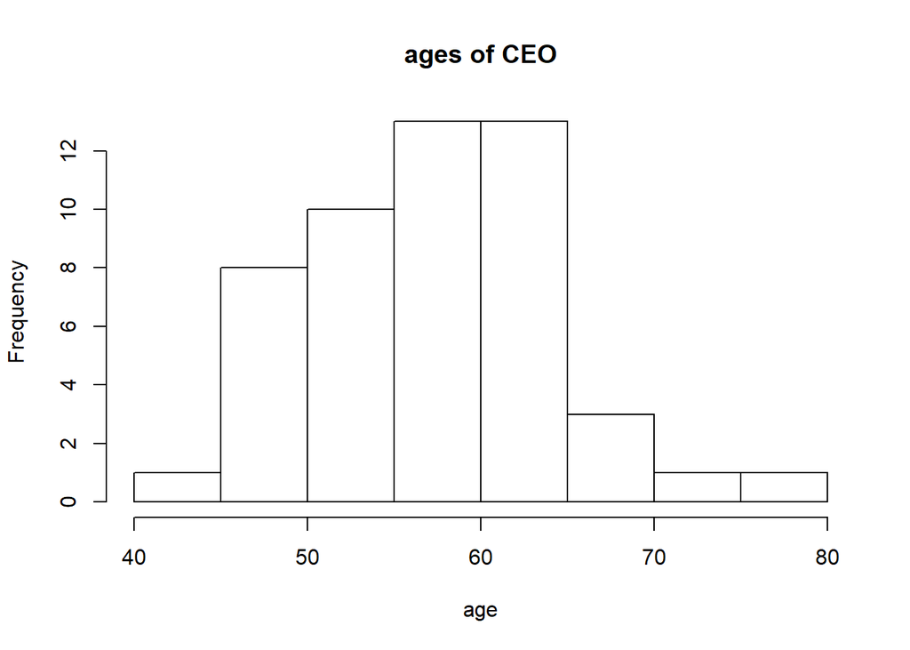

```r
hist(ages, breaks=10, main="ages of CEO", xlab="age")
```

## b

```r
stem(ages, scale = 1)
```

```
##
##   The decimal point is 1 digit(s) to the right of the |
##
##   4 | 2
##   4 | 7899
##   5 | 0000111244
##   5 | 55556777778899
##   6 | 0001122222334444
##   6 | 779
##   7 | 4
##   7 | 8
```

## c

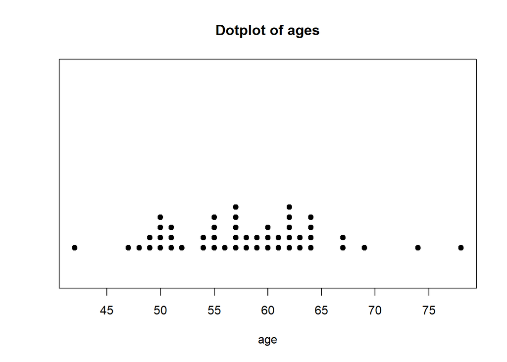

```r
stripchart(ages, method = "stack", offset = .7, at = .3, pch = 19,
           main = "Dotplot of ages", xlab = "age")
```

## d

```r
summary(ages)
```

```
##    Min. 1st Qu.  Median    Mean 3rd Qu.    Max.
##   42.00   52.50   57.50   57.84   62.00   78.00
```

不管以長條圖、莖葉圖還是點圖來看，此資料都為右偏，從summary的資料來看亦為右偏，最小值到第一四分位距以及到平均數的距離都較最大值為小，因此此資料為右偏

## e

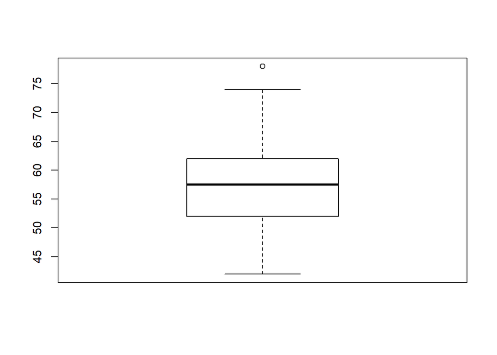

```r
boxplot(ages)
```

由盒狀圖的定義，只要有資料與q1或q3距離1.5個IQR，即為outlier。  
由上述盒狀圖所示，此資料具有outlier

## f

我覺得CEO的薪資比較有可能出現outlier。  
雖然是500大企業，但每個公司的資產規模差異可能頗大，痕容易有離群值，而CEO年齡的部分，最年輕到最老的全距本身就比較小，而且能擔任總裁到需要退休的年齡是可以想像的，相較於薪資比較不容易有特例。

# 2.66

```r
blood=c(110,123,132,150,127,118,102,122)
summary(blood)
```

```
##    Min. 1st Qu.  Median    Mean 3rd Qu.    Max.
##   102.0   116.0   122.5   123.0   128.2   150.0
```

## a

```r
median=122.5
```

## b

```r
lowerquartiles=116.0
upperquartiles=128.2
```

## c

```r
IQR=upperquartiles-lowerquartiles
IQR
```

```
## [1] 12.2
```

## d

```r
dw=lowerquartiles-1.5*IQR
#min=102.0
dw
```

```
## [1] 97.7
```

```r
up=upperquartiles+1.5*IQR
#max=150.0
up
```

```
## [1] 146.5
```

## e

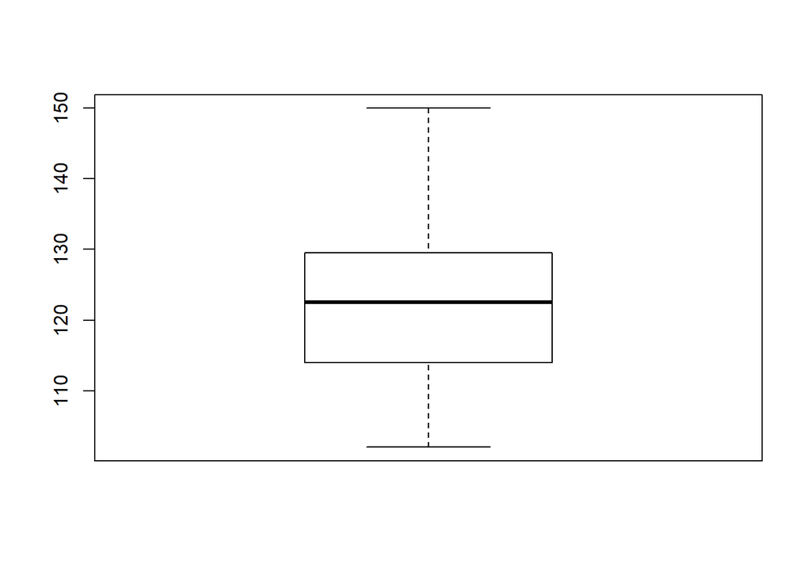

```r
boxplot(blood)
```

# 2.76

```r
group1=c(2,30,35,70,100,120,135,150,190,200)
group2=c(8,12,16,29,35,40,45,46,95)
```

## a

```r
summary(group1)
```

```
##    Min. 1st Qu.  Median    Mean 3rd Qu.    Max.
##    2.00   43.75  110.00  103.20  146.25  200.00
```

## b

```r
summary(group2)
```

```
##    Min. 1st Qu.  Median    Mean 3rd Qu.    Max.
##    8.00   16.00   35.00   36.22   45.00   95.00
```

## c

```r
max1=200
min1=2
max2=95
min2=8
range1=max1-min1
range2=max2-min2
range1
```

```
## [1] 198
```

```r
range2
```

```
## [1] 87
```

```r
range2<range1
```

```
## [1] TRUE
```

# d

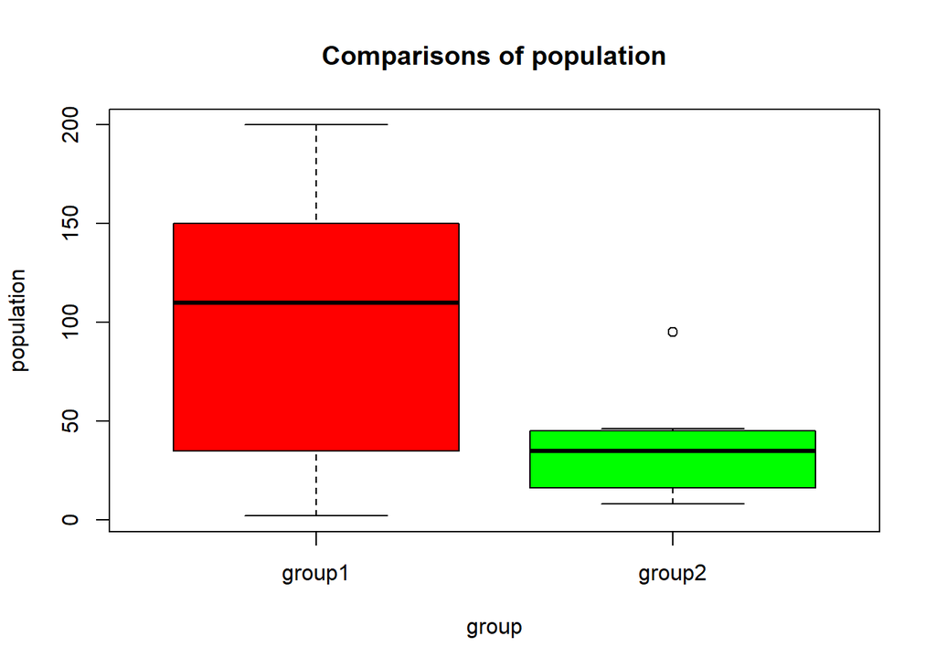

```r
all=list(group1=group1,group2=group2)
boxplot(all, col=(c("red","green")),main="Comparisons of population", xlab="group", ylab="population")
```

# 2.96

```r
mean=70
sd1=5
sd2=15
mean+sd1
```

```
## [1] 75
```

```r
mean+sd2
```

```
## [1] 85
```

在標準差為5的情況下，若資料為常態分佈，則有(68+16)%的人成績低於75分，而(95+2.5)%的人低於80分，因此若考80分代表成績位於前面2.5%  
而若標準差為15，在常態分佈下，有(68+16)%的人成績低85分，因此若考80分代表成績位於前面16%之後  
因此在平均相同且同樣考80分的狀態下，標準差為5的時候代表表現較好

# 2.104

```r
mean=56
sd=2
```

## a

在常態分佈下，有95%的人距離平均數兩個標準差之內，因此頭型最小的2.5%的人頭圍小於平均數減2個標準差

```r
mean-2*sd
```

```
## [1] 52
```

## b

在常態分佈下，有95%的人距離平均數兩個標準差之內，因此頭型最大的2.5%的人頭圍大於平均數加2個標準差

```r
mean+2*sd
```

```
## [1] 60
```

## c

在常態分佈下，有68%的人距離平均數一個標準差之內，因此頭型大小的16%的人頭圍小於平均數加1個標準差

```r
mean+sd
```

```
## [1] 58
```